*The section below was envisioned as an addition to [this NYT article](https://www.nytimes.com/2023/01/30/science/archaeology-bogs-mummies.html) about [new research](https://www.cambridge.org/core/journals/antiquity/article/bogs-bones-and-bodies-the-deposition-of-human-remains-in-northern-european-mires-9000-bcad-1900/B90A16A211894CB87906A7BCFC0B2FC7#) on mummified remains in European bogs.*

### Unearthing insights

The study offers the first large-scale overview of well-dated human remains from northern European mires, with the principal goal to identify broad trends in frequency, location, and characteristics of finds. Researchers compiled a database consisting of 266 sites and more than 1,000 individuals. Using statistical modelling, they identified six major phases in history for this phenomenon. The main characteristics that distinguish each phase can be explored below.

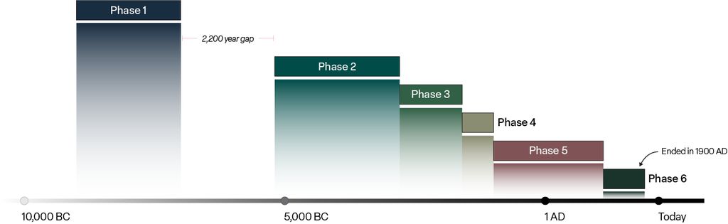

#### Spatial

The first sites appear in Denmark, southern Sweden and Norway. In phases 2 and 3, sites pop up in Ireland and the UK. The coverage area increases to include Germany, Poland, and the Baltic states in phase 5. In phase 6 a significant shift occurs from Denmark to Ireland and the UK.

[interactive chart not shown]

Filter by phase

1 2 3 4 5 6

#### Preservation

Phase 1 and 2 sites yielded only bog skeletons. The first bog mummies don't appear until later, in phases 3 and 4, with just five bog mummies from before 1,000 BC. Phase 5 features a far larger number of bog mummies, although they still represent fewer than half of cases. The balance completely shifts in phase 6.

[interactive chart not shown]

#### Age

Adults are most common throughout all phases. Children are present to a lesser degree in each phase, though missing entirely from phase 4. The age for 26 individuals could not be determined or is otherwise unknown.

[interactive chart not shown]

#### Sex

Males form the largest group in most phases. However, in phases 2 and 4 the balance is almost equal between males and females. The sex of 89 individuals could not be determined or is otherwise unknown.

[interactive chart not shown]

#### Cause of Death

Cause of death is established for 57 individuals. In 45 cases, violence was involved, featuring in all phases except for phase 1. The highest proportions of violent deaths appear in phases 2 and 6. Evidence of violence appears to be less frequent in phase 4. In rare cases, only occurring in phase 5, disease is the probable cause of death. Phase 6 includes six suicide victims and four cases of accidental death (e.g. drowning).

[interactive chart not shown]

#### Violence

[interactive chart not shown]

#### Study Impact

This approach shows that widening the study’s focus to encompass a larger study region, longer timeframe, the incorporation of bog mummies as well as bog skeletons, and the inclusion of both radiocarbon and historical dating evidence, permits new trends to come to light. The full database, freely available here, offers great potential for the recognition of other trends and for further study.